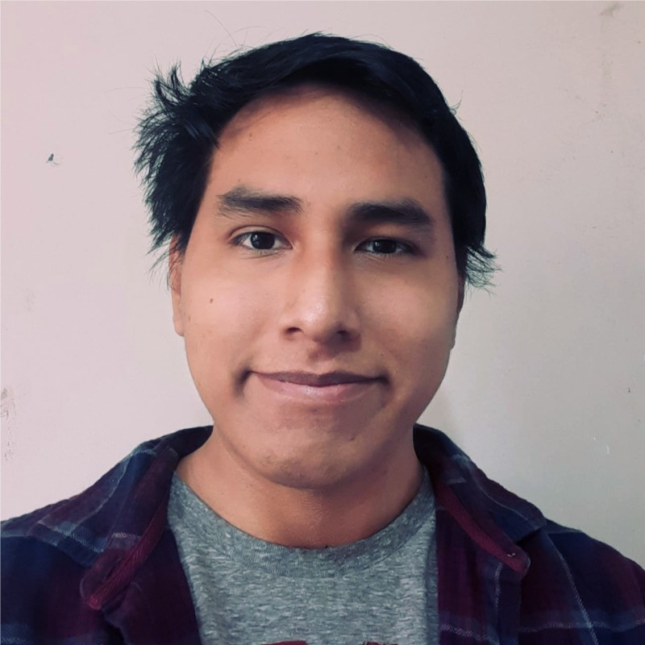

# Daniel Desposorio

#### About me

Biologist with a strong research interest in cancer genomics, transcriptomics, and precision oncology. Passionate about applying genomics and bioinformatics to investigate the molecular mechanisms underlying cancer development and progression, with a particular focus on gene regulation, aberrant gene expression, and the activation of oncogenic pathways that drive tumor initiation and progression.

#### **Education**

B.Sc. in Biology | Universidad Nacional Federico Villareal, Peru | April 2019 – January 2024

#### **Experience**

- **Bioinformatics Research Intern** | Laboratorio Internacional de Investigación sobre el Genoma Humano (LIIGH-UNAM) | Querétaro, Mexico | **2026**

  Applied bioinformatics approaches for the analysis and interpretation of genomic data in cancer research.
- **Standardization and Validation of Multiplex Real-Time PCR for the Detection of Antimicrobial Resistance Genes** | Instituto Nacional de Salud (INS) | Lima, Peru | **2024**

  Contributed to the optimization and validation of multiplex qPCR assays for the detection of clinically relevant antimicrobial resistance genes.
- **Quantification of Pathogens and Correlation with the Relative Abundance of Antimicrobial Resistance Genes in Chicken Carcasses** *(Undergraduate Thesis)* | Laboratorio de bioquimica y biología molecular - Universidad Nacional Federico Villareal | Lima, Peru | **2024**

  Conducted microbiological, molecular, and statistical analyses to evaluate the relationship between foodborne pathogens and antimicrobial resistance gene abundance in poultry samples.